# Pillar objects of R

## Objects

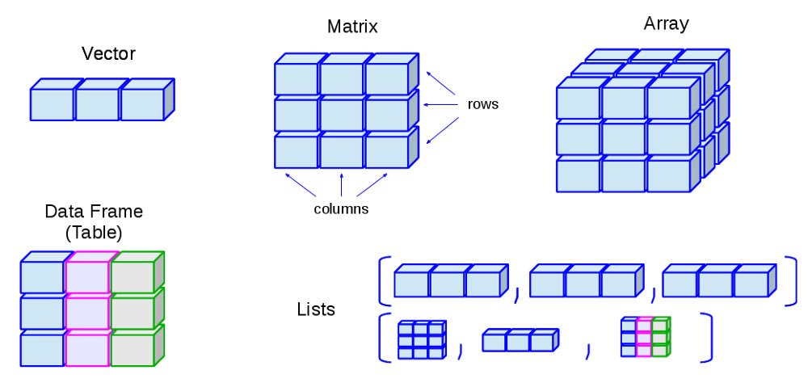

## Vector

```r
x <- c(0.5, 0.6)
print(x)
```

```
[1] 0.5 0.6
```

```r
x <- c(TRUE, FALSE)
print(x)
```

```
[1]  TRUE FALSE
```

```r
x <- c("a", "b", "c")
print(x)
```

```
[1] "a" "b" "c"
```

```r
x <- 9:29
print(x)
```

```
 [1]  9 10 11 12 13 14 15 16 17 18 19 20 21 22 23 24 25 26 27 28 29
```

## Matrix

- Vector with dimension atrribute
- A matrix is a two-dimensional array
- matrix()
- nrow
- ncol
- m <- matrix(nrow = 3, ncol = 3, byrow=T)
- every element must be the same class

```r
 matrix(9:20,nrow = 4, ncol = 3, byrow=T)
```

```
     [,1] [,2] [,3]
[1,]    9   10   11
[2,]   12   13   14
[3,]   15   16   17
[4,]   18   19   20
```

## Matrix

- use rownames() to name the rows
- use colnames() to name the columns

## Matrix

```r
x<-c(1:2)
y<-c(5:6)
m<-matrix(c(x,y), nrow=2, ncol=2, byrow = T) #combining vectors to matrix
m
```

```
     [,1] [,2]
[1,]    1    2
[2,]    5    6
```

```r
rownames(m)<-c("FirstRow","SecondRow")  #changing row names
colnames(m)<-c("Col1","Col2") #changing col names
m
```

```
          Col1 Col2
FirstRow     1    2
SecondRow    5    6
```

## Matrix

- transposing matrix with the function t()

```r
t(m)
```

```
     FirstRow SecondRow
Col1        1         5
Col2        2         6
```

## List

- Very important object
- Essential part in loops
- list() and as.list() – number of parameters

```r
list(1,2)
```

```
[[1]]
[1] 1

[[2]]
[1] 2
```

```r
as.list(c(1,2))
```

```
[[1]]
[1] 1

[[2]]
[1] 2
```

## List

- named elements in list

```r
list(firstElement=c(1:4), secondElement=c("Chris","Jane"))
```

```
$firstElement
[1] 1 2 3 4

$secondElement
[1] "Chris" "Jane"
```

## List

- appending new elements to list
- append(), c()

```r
newList=list()
newList<-append(newList,1)
newList
```

```
[[1]]
[1] 1
```

```r
newlist<-c(newList,2)
newlist
```

```
[[1]]
[1] 1

[[2]]
[1] 2
```

## Data frame/tibble

- store tabular data
- used in a variety of statistical modeling applications
- different classes of objects in each column
- usually created by read.table() or read.csv()
- data.frame() and as.data.frame()
- tibble is modern representation of dataframe

```r
data.frame(id=c(1:3),Names=c("Jane","Joe","Jim"))
```

```
  id Names
1  1  Jane
2  2   Joe
3  3   Jim
```

## Data frame vs. tibble

- tibble is a subtype of a data frame that is optimized for data science applications
- part of Hadley Wickham’s tidy verse family of vCard classes
- tibbles also have an enhanced print() method which makes them easier to use with large datasets
- as.tibble()–> as_tibble()

## Factors

- variable is discrete when every value is taken from a limited pool of possible values
- variable is continuous if the pool of possible values is not limited
- discrete values can be nominal or categorical (without any specific order)
- ordinal where a logical ordering of the values makes sense
- discrete variables are called factors (in R)

## Factors

- You define factors from vectors of values with the factor() function
- alphabetical order

```r
x <- c("good", "moderate", "good", "bad", "bad", "good")
y <- factor(x); y
```

```
[1] good     moderate good     bad      bad      good
Levels: bad good moderate
```

```r
w <- factor(x, order = TRUE, levels = c("bad", "moderate", "good")); w
```

```
[1] good     moderate good     bad      bad      good
Levels: bad < moderate < good
```

```r
gender<-factor(c("Male", "Female","Female","Male"))
gender
```

```
[1] Male   Female Female Male
Levels: Female Male
```

## Factors

- gl() to create factors
- levels(): returns the levels of factor

```r
z<-gl(3, 9, labels = c("Apple", "Banana","Orange"));z
```

```
 [1] Apple  Apple  Apple  Apple  Apple  Apple  Apple  Apple  Apple  Banana
[11] Banana Banana Banana Banana Banana Banana Banana Banana Orange Orange
[21] Orange Orange Orange Orange Orange Orange Orange
Levels: Apple Banana Orange
```

```r
levels(z)
```

```
[1] "Apple"  "Banana" "Orange"
```

```r
levels(z)[2]<-"Lemon";z
```

```
 [1] Apple  Apple  Apple  Apple  Apple  Apple  Apple  Apple  Apple  Lemon
[11] Lemon  Lemon  Lemon  Lemon  Lemon  Lemon  Lemon  Lemon  Orange Orange
[21] Orange Orange Orange Orange Orange Orange Orange
Levels: Apple Lemon Orange
```

## Factors

- numeric values to factors, e.g. age to age groups
- using cut()

```r
#creating 100 age value with mean=60 and sd=20
age = rnorm(100, mean = 60, sd = 20)
#creating factors <50; 50-70; >70
ageF<-factor(cut(age,breaks=c(min(age),50,70,max(age))),
             labels = c("<50","50-70",">70"))
levels(ageF)
```

```
[1] "<50"   "50-70" ">70"
```

```r
# using summary function to show the frequency
summary(ageF)
```

```
  <50 50-70   >70  NA's
   34    34    31     1
```

```r
# do you see the problem?
```

## Exploring objects

- str() -> object‘s structure
- dim() -> object‘s dimensions

```r
df<-data.frame(id=c(1:3),Names=c("Jane","Joe","Jim"))

str(df)
```

```
'data.frame':   3 obs. of  2 variables:
 $ id   : int  1 2 3
 $ Names: chr  "Jane" "Joe" "Jim"
```

```r
dim(df)
```

```
[1] 3 2
```

```r
m <-matrix(9:20,nrow = 4, ncol = 3, byrow=T)

dim(m)
```

```
[1] 4 3
```

```r
str(m)
```

```
 int [1:4, 1:3] 9 12 15 18 10 13 16 19 11 14 ...
```

## Lab

- create a new script and name it lab1
- create numeric vector with 100 elements
- create list with 10 elements
- create matrix with 10 rows and 5 columns
- create list with 5 named elements
- create dataframe with 4 columns (col1, col2, col3, col4)
- open matrix.txt and complete the tasks
- open factors.txt and complete the tasks